# Introduction to R

Session 1

# Session Overview

1. What is R?
2. First Steps in R
3. What is RStudio?
4. First Steps in RStudio
5. R Script
6. R Package Management System
7. Inputs and Outputs

# What is R?

## What is R?

**R**

- is an open-source statistical programming language.
- available for most operating systems
- helps users analyze, visualize, and model data—from simple summaries to complex data analysis
- is extremely popular in statistics and data science, see [this article](http://r4stats.com/articles/popularity/)
- includes thousands of packages (add-ons) that can be used for specialized tasks without a deep understanding of the language and programming skills
- allows for extensive programming, making it also suitable for advanced or case-specific applications of statistical methods

The combination of the latter two aspects sets **R** apart and makes it useful for everything ranging from standard ‘basic’ statistical analysis to the development of new methods.

The homepage of **R** is www.r-project.org from which you can install **R** and access manuals that provide detailed information about installing and using **R**.

# First Steps in R

## Opening R

Open **R**, you should see the following:

[figure not shown]

## Opening R

The program window provides some basic information on **R** and the installed version.

Check your version of **R**!

[figure not shown]

## R Console

The **R** Console can be used to directly give in commands and display output:

[figure not shown]

## R Prompt

Under the default information, you can see the **R** prompt, through which **R** indicates that it is ready to execute a new command.

[figure not shown]

## Executing your first command

Start by using **R** as a simple calculator, try to enter after the **R** prompt:

```r
2+3
```

and hit *enter*.

You will see that **R** directly returns the output in the **R** console next to the ‘[1]’:

```r
2+3
```

```
[1] 5
```

If you want to re-execute your previous command, use the arrow key *↑*. To make changes to a command, you can use the *←, →* arrows and re-execute. To move to the next command, use the *↓* arrow.

Finally, when **R** receives an incomplete expression such as

```r
2+
```

**R** will return the *+* symbol, thereby letting you know that you forgot to type something. You can either complete the command and then hit *enter* or exit the incomplete command via the *esc* button.

## Exercise 1.1

Enter the following expressions, one by one, in **R** and hit *enter* to see how **R** evaluates them:

```r
2 + 3*4

(2 + 3)*4

(2 + 3*4

sqrt(4)

pi
```

## From R to Rstudio

After taking your first steps in **R**, you might not be impressed by the design of the user interface and the way the software is used.

There are various user interfaces that work on top of plain **R** to make it more user friendly. A very popular one is **RStudio**.

# What is RStudio?

## What is RStudio?

**RStudio**

- is an Integrated Development Environment (IDE) for **R**
- is a user-friendly interface for writing and running **R** code
- makes it easier to write code, analyze data, create visuals, access documentation and manage projects

Its homepage is https://posit.co/download/rstudio-desktop/

# First Steps in RStudio

## Opening RStudio

Open **RStudio**, you should see the following:

[figure not shown]

## Opening RStudio

You will recognize the **R** Console and see that **RStudio** is ready to receive input:

[figure not shown]

## Exercise 1.2

Re-execute the commands you executed before in **R** now in the **R** Console of **RStudio**:

```r
2 + 3*4

(2 + 3)*4

(2 + 3*4

sqrt(4)

pi
```

The console in **RStudio** behaves exactly the same as the plain **R** window!

## Structure in RStudio

But **RStudio** has much more to offer than plain **R**!

**RStudio** (unlike **R**) is structured in different windows. You should currently see 3 windows:

- Left: **R** console
- Top right: Display of objects in the global environment
- Bottom right: Files, plots, packages, help, etc.

## RStudio Windows

The 3 main windows (aka panes) in **RStudio**:

[figure not shown]

## RStudio Menu Bar

**RStudio** also has a Menu bar at the top:

[figure not shown]

The usefulness of these windows and menu bar in **RStudio** will become clear throughout this training.

## Exercise 1.3

Explore the following quick tricks that the console in **RStudio** offers. After the prompt:

- press the *ctrl* button on Windows, or the *command* on Mac together with the arrow key *↑*. What do you see?

It should give you a list of all previously executed commands. You can then use the *↑* and *↓* arrow keys to directly move to a certain command to repeat or correct it.

- start to write sq and then hit the tabulator (tab) key *⇆* right after without an additional space. What do you see?

It should present you with a list of suggested commands together with a short description. You can then use the *↑* and *↓* arrow keys to navigate through them. Which one is the relevant one to compute the square root of a number? Choose the appropriate function, then hit *enter* to compute the square root of 100.

## Need for R Scripts

Suppose you want to continue your work tomorrow. If you would now close **RStudio**, all of your work would be gone!

To avoid this problem, we will not give commands directly in the **R** console, but save them in an **R** Script.

# R Script

## What is an R Script?

While many simple calculations can be done using the command line, as soon as things get more complicated, scripts should be used.

An **R** Script

- is a plain text file that contains a collection of **R** commands
- is written in such a form to perform commands in a step by step fashion
- contains all commands including those for importing data, analyzing data, visualizing data or other tasks
- can be saved as a .R file
- allows you to automate and reproduce your work, allowing you to run the same analysis without having to redo each step manually again
- makes your work organized, shareable and transparent!

## Creating an R Script

Creating an **R** Script is easy.

Using the menu bar, go to *File* -> *New File* -> *R Script*:

[figure not shown]

Alternatively, you could have used the shortcut *ctrl+shift+N* on Windows or *command+shift+N* on Mac.

## Structure in RStudio

RStudio now displays 4 windows, with the **R** Script currently displayed in the top left:

[figure not shown]

## R Script

Currently the **R** Script is Untitled, we should give it a name.

[figure not shown]

## Exercise 1.4

Give your R Script a name and save it. Go to *File* -> *Save As…*:

[figure not shown]

## Exercise 1.5

Copy some of the commands you previously executed into your **R** Script.

Execute a specific line

- by pressing the *Run* button to execute the line on which your cursor is currently located
- by using *ctrl+enter* on Windows or *command+enter* on Mac to execute the line on which your cursor is currently located

[figure not shown]

You can execute multiple lines by highlighting them all and doing one of the above. Try this.

## Exercise 1.6

You can adjust the sizes and positioning of the windows (panes) according to your liking.

Go to *Tools*, *Global Options…* and then select *Pane Layout* from which you can adjust the positioning of each of the 4 panes by selecting them from the drop-down menus

[figure not shown]

Experiment with a different positioning and re-adjust according to your liking.

# R Package Management System

## R Package Management System

Until now, we have explored some basic functionality in **R**. But much of the functionality of **R** is extended by its big and active community.

These extensions are called **R** packages

## What are R packages?

**R** packages

- are constantly developed and adjusted by the large user community making many state-of-the-art methods quickly available
- can be installed for just about everything you want to do in statistics and data science
- offer pre-defined functions which makes it possible to use **R** without a deep understanding of the language and programming skills.

## Overview of R packages

The standard distribution of **R** comes already with a number of packages.

A list of the currently installed packages can be obtained from the *Packages* window in the bottom right window below

[figure not shown]

You can install new packages depending on your needs. We will explore R packages in much more detail in the upcoming sessions!

# Input and Output

## Inputs and outputs of your R session

- Common inputs / outputs of an **R** session are datasets or **R** scripts.
- For this meeting we focus on datasets as inputs to the **R** session, loading data and saving data.
- The file format (csv, RData, xls, stata …) and directory of the files are important to keep in mind.
- We will go over a few options, potential issues, and how to avoid the need to type in a long directory name when managing the input and output of the **R** session.

## R Working Directory

Before we start working in our R Script, let us first set the working directory in **R**.

The working directory is the location on your computer where **R** will read and save files. Go to *Session* -> *Set Working Directory*. Two convenient options are:

- *Choose Directory…*: Choose the directory yourself
- *To Source File Location*: Set the working directory to the directory where your **R** Script (the source file) is saved

[figure not shown]

## R Working Directory

Select the option to set the working directory to the source file location. You will see that a command automatically pops up in the R console, something like:

```r
setwd("C:/Rtraining")
```

You can use this command directly next time. Mind the usage of the */* when specifying the path of your working directory!

You can also include comment lines in your **R** script. These start with the symbol *#* and allow you to document your code. For instance:

```r
# Setting my working directory
setwd("C:/Rtraining")
```

Finally, to retrieve your working directory you can use

```r
  getwd()
```

## R Working Directory

A very useful package to set your working directory in **R** is the package `this.path`. Install this **R** package.

To set the working directory to the folder where your current R script is located, you can simply use:

```r
library(this.path)
setwd(here())
```

## Input and Output Types

**R** interacts with files in several ways.

- You can load, save, import, or export a data file.
- You can save a generated figure as a graphics file or store regression tables as text, spreadsheet, or LATEX tables.
- You can load, save the full workspace (environment) you are working with to follow up another time.

Datasets can come in different formats.

## Loading RData files

- RData files are specific to **R** file formats.
- They can store a single object or several objects.
- These files are the easiest to manage as input or output in **R**, since they don’t require library calls.

## Loading RData files: Example

Download the data file climate_long.RData from the training website. Create a directory ‘data’ in your working directory. Save the Rdata file in this data directory.

You can now use the following lines of code to load your data and inspect it:

```r
load("data/climate_long.Rdata")
print(long_data)
```

```
             NAME MONTH TEMP
99091   EINDHOVEN     1 10.6
99122   EINDHOVEN     2  7.1
99151   EINDHOVEN     3 10.2
99178   EINDHOVEN     4  8.9
99207   EINDHOVEN     5 18.5
99238   EINDHOVEN     6 15.0
99268   EINDHOVEN     7 15.0
99299   EINDHOVEN     8 20.7
99329   EINDHOVEN     9 22.6
99359   EINDHOVEN    10 10.0
99390   EINDHOVEN    11 10.5
99415   EINDHOVEN    12  9.7
99801  MAASTRICHT     1  9.7
99832  MAASTRICHT     2  5.9
99861  MAASTRICHT     3  9.9
99888  MAASTRICHT     4  9.0
99917  MAASTRICHT     5 15.7
99948  MAASTRICHT     6 14.1
99978  MAASTRICHT     7 14.9
100009 MAASTRICHT     8 20.5
100039 MAASTRICHT     9 21.6
100069 MAASTRICHT    10 10.3
100100 MAASTRICHT    11 10.2
100125 MAASTRICHT    12  9.2
```

The data is loaded as a dataframe (in long format), we will learn more about dataframes and formats in the next sessions.

## Loading Other Formats of Data in R

Option 1: Using menus within RStudio is the easiest (click and go) but requires using the menu every time the user runs the code.

[figure not shown]

## Loading Other Formats of Data in R

Option 1: Using menus within RStudio (cont’d)

[figure not shown]

## Loading Other Formats of Data in R

Option 1: Using menus within RStudio (cont’d)

[figure not shown]

## Loading Other Formats of Data in R

Option 1: Using menus within RStudio (cont’d)

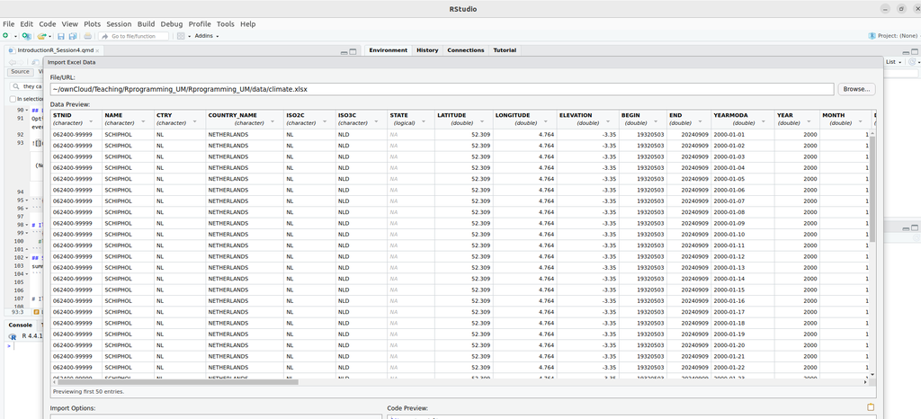

## Loading Other Formats of Data in R

Advice for option 1:

- Copy the command that appears after loading the data from the menus.

[figure not shown]

## Loading Other Formats of Data in R

Advice for option 1 (cont’d):

- Paste the command on top of your script.
- This way, next time you do not need the menu navigation.
- Note that you need to install the package `readxl` to use its functionality.

```r
library(readxl)
climate <- read_excel("data/climate_wide.xlsx")
```

- You can view the data by clicking on it in the `Environment’ at the top-right of the workspace.

## General Advice

- Using the correct libraries for different data formats can be tedious.
- **R** package `rio` is very convenient for data import and export. It figures out the type of data format from the file name extension, e.g. *.csv for CSV,* .dta for Stata, or *.sav for SPSS data sets
- It calls an appropriate package to do the actual importing or exporting.

## Exercise 1.7

- Download the file climate.csv from the training website.
- Save it in your data folder.
- Install the **R** package `rio`.
- Use the import function from the package `rio` to import the climate.csv file.
- Inspect the data.

## Loading data from APIs

- It is possible to automatically load data from a web source using APIs.
- An API (Application Programming Interface) acts as a bridge between your **R** code and an external data source: a website, database, or an online platform with permissions.
- Advantages: Automation, efficiency and real-time access.
- Disadvantages: No offline access to data (can be important for replication), dependency on external services (API can go down).
- Suggestion: Save the downloaded data in RData format to mitigate disadvantages.

## Loading data from APIs: Example

- As an example we will download AAPL daily prices from Yahoo Finance.
- Inspect the data

```r
library(quantmod)
# Get Apple Inc. (AAPL) stock data from Yahoo Finance
getSymbols("AAPL", src = "yahoo", from = "2024-01-01", to = "2025-06-13")
# View the data
View(AAPL)
```

## Exercise 1.8: Saving data

- Save your current workspace using function `save.image()`.
- Save only one variable in the workspace using function `save()`. Save the AAPL data in your directory data.